# Laptop Dataset

4/17/2022

## Exploring data

To get an overview of the data set, I use the `dim()` and `summary()` function to explore the data.

```r
dim(laptop)
```

```
## [1] 896  23
```

We can see that the laptop data set has 23 columns and 896 rows.

There are 896 observations or rows in this data set, and each of them is a kind of laptop that is on the market.

```r
summary(laptop)
```

```
##      brand          model     processor_brand processor_name processor_gnrtn
##  ASUS   :254   VivoBook: 89   AMD     :208    Core i5:312    11th   :346
##  DELL   :154   Inspiron: 77   Intel   :660    Core i3:170    10th   :246
##  Lenovo :148   Pavilion: 38   M1      : 24    Core i7:112    8th    : 43
##  HP     :142   IdeaPad : 37   MediaTek:  3    Ryzen 5: 85    7th    : 12
##  acer   : 58   Ryzen   : 35   Qualcomm:  1    Ryzen 7: 58    9th    :  6
##  MSI    : 52   (Other) :525                   Ryzen 3: 26    (Other):  4
##  (Other): 88   NA's    : 95                   (Other):133    NA's   :239
##       ram_gb       ram_type        ssd           hdd            os
##  16 GB GB:180   DDR3   : 12   512 GB :417   0 GB   :666   DOS    : 36
##  32 GB GB:  3   DDR4   :760   256 GB :201   1024 GB:164   Mac    : 28
##  4 GB GB :259   DDR5   :  8   0 GB   :151   2048 GB:  1   Windows:832
##  8 GB GB :454   LPDDR3 : 14   1024 GB:111   512 GB : 65
##                 LPDDR4 : 36   128 GB : 12
##                 LPDDR4X: 66   2048 GB:  2
##                               (Other):  2
##     os_bit    graphic_card_gb        weight     display_size    warranty
##  32-bit:135   0:631           Casual    :566   15.6   :218   Min.   :0.000
##  64-bit:761   2: 69           Gaming    : 39   16     :135   1st Qu.:0.000
##               4:138           ThinNlight:291   14     :131   Median :1.000
##               6: 40                            13.3   : 40   Mean   :0.692
##               8: 18                            17.3   :  9   3rd Qu.:1.000
##                                                (Other): 31   Max.   :3.000
##                                                NA's   :332
##  Touchscreen msoffice   latest_price      old_price         discount
##  No :793     No :606   Min.   : 181.9   Min.   :   0.0   Min.   : 0.00
##  Yes:103     Yes:290   1st Qu.: 591.4   1st Qu.: 714.2   1st Qu.:11.00
##                        Median : 825.4   Median :1014.7   Median :19.00
##                        Mean   : 992.0   Mean   :1145.7   Mean   :18.53
##                        3rd Qu.:1158.2   3rd Qu.:1443.3   3rd Qu.:26.00
##                        Max.   :5745.9   Max.   :4911.4   Max.   :57.00
##
##   star_rating      ratings           reviews
##  Min.   :0.00   Min.   :    0.0   Min.   :   0.00
##  1st Qu.:0.00   1st Qu.:    0.0   1st Qu.:   0.00
##  Median :4.10   Median :   19.0   Median :   3.00
##  Mean   :2.98   Mean   :  367.4   Mean   :  46.15
##  3rd Qu.:4.40   3rd Qu.:  179.5   3rd Qu.:  23.25
##  Max.   :5.00   Max.   :15279.0   Max.   :1947.00
##
```

| Column name | Description | Type of data |
| --- | --- | --- |
| brand | Brand | Text |
| model | Model | Text |
| processor_brand | Processor Brand | Text |
| processor_name | DProcessor Name | Text |
| processor_gnrtn | Processor Generation | Text |
| ram_gb | RAM in GB | Numeric |
| ram_type | RAM Type | Text |
| ssd | SSD in GB | Numeric |
| hdd | HDD in GB | Numeric |
| os | Operating System | Text |
| os_bit | OS-Bit | Text |
| graphic_card_gb | GPU in GB | Numeric |
| weight | Weight | Text |
| display_size | Size in Inches | Numeric |
| warranty | Warranty in Years | Numeric |
| Touchscreen | Touchscreen | Text |
| msoffice | MS Office | Text |
| latest_price | Latest Price | Numeric |
| old_price | Original Price | Numeric |
| discount | Discount | Numeric |
| star_rating | Rating out of 5 stars | Text |
| ratings | Total Ratings | Numeric |
| review | Total Reviews | Numeri |

#### Missing data

Next, we are looking at the missing data.

There are only 3 variables that contains missing data which are model (10.6%), processor generation (26.67%), and display size (37.05%). Overall, 3.2% of data is missing and the rest 96.8% is present.

```r
sum(is.na(laptop))
```

```
## [1] 666
```

```r
colMeans(is.na(laptop))*100
```

```
##           brand           model processor_brand  processor_name processor_gnrtn
##         0.00000        10.60268         0.00000         0.00000        26.67411
##          ram_gb        ram_type             ssd             hdd              os
##         0.00000         0.00000         0.00000         0.00000         0.00000
##          os_bit graphic_card_gb          weight    display_size        warranty
##         0.00000         0.00000         0.00000        37.05357         0.00000
##     Touchscreen        msoffice    latest_price       old_price        discount
##         0.00000         0.00000         0.00000         0.00000         0.00000
##     star_rating         ratings         reviews
##         0.00000         0.00000         0.00000
```

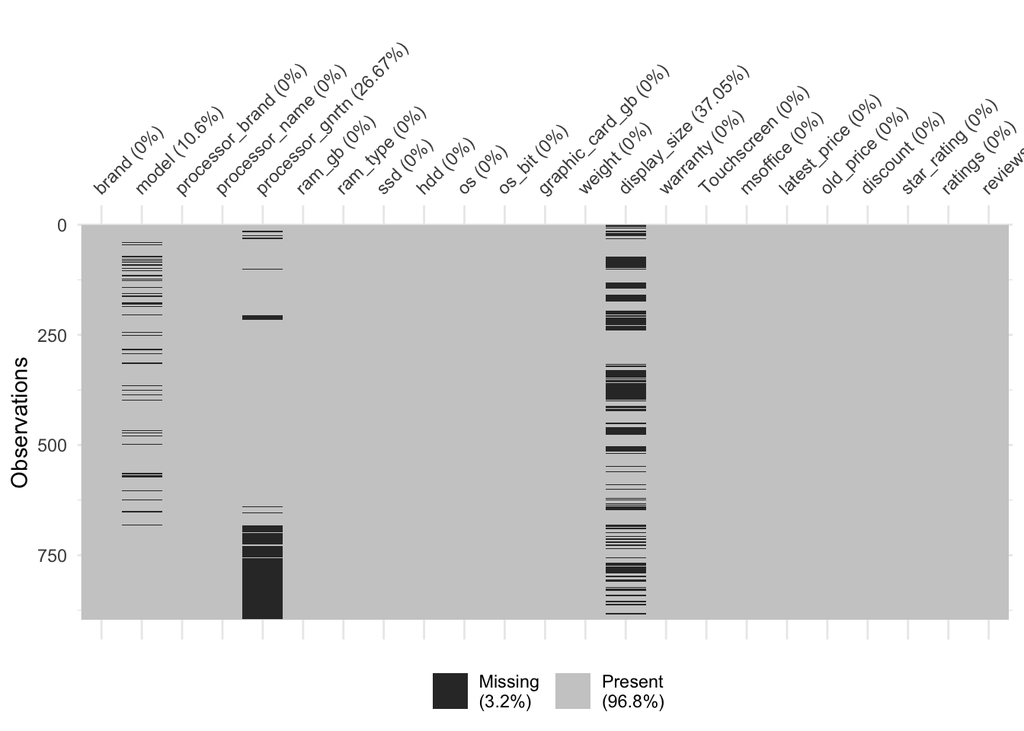

```r
vis_miss(laptop)
```

## Question 1

- How does different gigabytes of RAM affect laptop prices?

To answer this question, I used box plot to see the distribution of price throughout different amount of gigabyte.

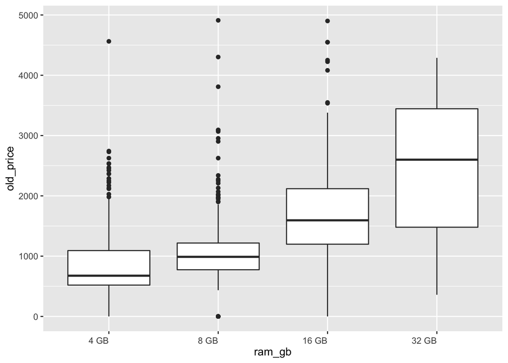

```r
ggplot(laptop, aes(x=ram_gb, y=old_price)) + geom_boxplot() +
  theme(axis.text.x = element_text(vjust = 0.5, hjust=1))+
  scale_x_discrete("ram_gb", limits = c("4 GB GB","8 GB GB","16 GB GB","32 GB GB"),
                   labels = c("4 GB GB" = "4 GB",
                              "8 GB GB" = "8 GB",
                              "16 GB GB"= "16 GB",
                              "32 GB GB"= "32 GB"))
```

## Question 2

- Which brand has the highest diminishing value in their laptop over time?

In the data set, we have 2 variable regarding prices which are original prices and latest price. Over the year, prices of laptop will have a discount because of the evolving technology and innovation. The answer to this question will help us to understand which brand has the lower value of laptops. We are using a bar plot to answer this question.

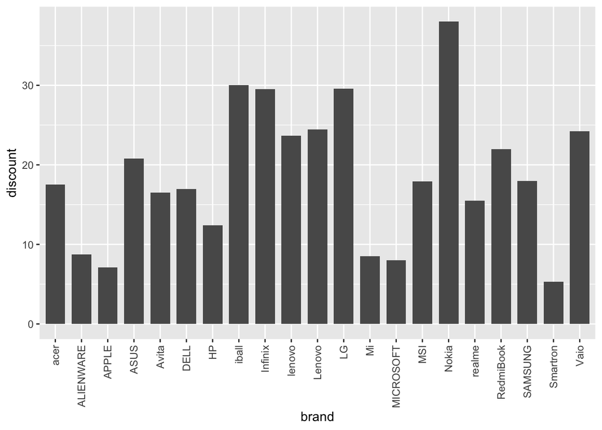

```r
ggplot(data=laptop) +
  geom_bar(aes(x=brand, y = discount),
           stat = "summary",
           fun = "mean", width=0.75) +
  theme(axis.text.x = element_text(angle = 90, hjust = 1, vjust = 0.5))
```